# Paper-plots

Vincent Fischer & Miriam Kretschmer

23/10/2026

```r
suppressPackageStartupMessages({
library(AnnotationHub)
library(rtracklayer)
library(universalmotif)
library(MotifDb)
library(Rsamtools)
library(memes)
library(rGREAT)
library(MotifDb)
library(ggplot2)
library(ggpubr)
library(ggrepel)
library(SummarizedExperiment)
library(SEtools)
library(sechm)
library(fgsea)
library(msigdbr)
library(RColorBrewer)
library(ggvenn)
library(viridis)
library(cowplot)
library(epiwraps)
  library(chromVAR)
  library(edgeR)
  library(limma)
  library(org.Hs.eg.db)
  library(org.Mm.eg.db)
  library(clusterProfiler)
  library(GenomeInfoDb)
  library(lme4)
  library(multcomp)
  })
set.seed(123)
ah <- AnnotationHub()
```

```r
theme_set(theme_classic())
source("objects/BFA_BFF.R")
source("objects/DLCAnalyzer.R")
```

```r
plotTransVF <- function(us, analysis = NULL, labels = NULL, title = NULL){
  require(ggplot2)
  require(cowplot)
  if(is.null(analysis)){
    analysis <- names(us$Results)
  }
  if(is.null(labels)){
    for(i in analysis){
      labels <- unique(c(labels, names(us$Results[[i]]$TransitionStats)))
    }
  }

  ps <- list()
  for(i in analysis){
    for(j in labels[labels %in% names(us$Results[[i]]$TransitionStats)]){
      bdat <- data.frame(distance = us$Results[[i]]$TransitionStats[[j]]$bootstraps)
      dis <- us$Results[[i]]$TransitionStats[[j]]$distance
      sigma <- us$Results[[i]]$TransitionStats[[j]]$sigma
      percentile <- us$Results[[i]]$TransitionStats[[j]]$percentile
      p1 <- ggplot(bdat,aes(distance)) +
        geom_histogram(color = "black", fill = "gray70", bins = 30) +
        geom_vline(xintercept = dis, color = "orange") +
        ylab("Frequency")+
        xlab("Manhattan Distance")+
        ggtitle(title)+

annotate("label",
         x = Inf, y = Inf,
         label = paste0("percentile: ", signif(percentile, 4), "\n",
                        "sigma: ", round(sigma, 2), "\n",
                        "p.value: ", signif((1 - pracma::erf(sigma / sqrt(2))) / 2, 3)),
         hjust = 1.05, vjust = 1.1,         # nudges inward from top-right
         size =5,                        # larger text
         label.size = 0.5,                  # thicker border
         fill = "white",                    # background color
         color = "black",                   # text color
         fontface = "plain",                # normal weight
         family = "Helvetica",                  # optional: use serif font
         lineheight = 1.1                   # spacing between lines
)

    ps[[paste(i,j, sep = "-")]] <- cowplot::plot_grid(p1, nrow = 1,rel_widths = c(1))


    }
  }
  cowplot::plot_grid(plotlist = ps, ncol = 1)
}
```

# 1 Fig 1A - Motif enrichment sperm and oocyte

```r
d.sperm <- readRDS("objects/motif_enrichment_sperm_consensus_narrow_HO11.rds")
# d.sperm <- readRDS("objects/motif_enrichment_sperm_consensus_broad.rds")

head(d.sperm)
```

| rank | motif_db | motif_id | motif_alt_id | consensus | pvalue | adj.pvalue | evalue | tests | fasta_max | pos | neg | pwm_min | tp | tp_percent | fp | fp_percent |
| --- | --- | --- | --- | --- | --- | --- | --- | --- | --- | --- | --- | --- | --- | --- | --- | --- |
| 1 | /tmp/RtmpvNu5qB/ANDR | ANDR_MOUSE.H11MO.0.A | NA | RGAACABYSTGTTCYB | 1.52e-305 | 2.66e-305 | 9.52e-305 | 17527 | 41384 | 41384 | 41384 | 2.31 | 11315 | 27.34 | 2206 | 5.33 |
| 2 | /tmp/RtmpvNu5qB/GCR | GCR_MOUSE.H11MO.0.A | NA | RGRACASRVTGTYCY | 4.66e-305 | 1.06e-305 | 3.81e-305 | 22859 | 41384 | 41384 | 41384 | 5.13 | 10308 | 24.91 | 1738 | 4.20 |
| 3 | /tmp/RtmpvNu5qB/PRGR | PRGR_MOUSE.H11MO.0.A | NA | RGAACARRVTGTYCY | 6.13e-305 | 1.38e-305 | 4.93e-305 | 22464 | 41384 | 41384 | 41384 | 4.04 | 10847 | 26.21 | 2047 | 4.95 |
| 4 | /tmp/RtmpvNu5qB/SP4 | SP4_MOUSE.H11MO.0.B | NA | SRGVARGRGGCGGRGCHDRR | 1.73e-305 | 4.95e-305 | 1.77e-305 | 28588 | 41384 | 41384 | 41384 | 11.00 | 6834 | 16.51 | 1690 | 4.08 |
| 5 | /tmp/RtmpvNu5qB/SP3 | SP3_MOUSE.H11MO.0.B | NA | SGVVGGGGGCGGGGCBRGSS | 1.21e-305 | 3.28e-305 | 1.17e-305 | 27096 | 41384 | 41384 | 41384 | 20.40 | 6027 | 14.56 | 1398 | 3.38 |
| 6 | /tmp/RtmpvNu5qB/KLF3 | KLF3_MOUSE.H11MO.0.A | NA | GGRGVDGGGCGGGGCYGGG | 3.71e-305 | 8.14e-305 | 2.91e-305 | 21961 | 41384 | 41384 | 41384 | 13.30 | 6014 | 14.53 | 1444 | 3.49 |

```r
length(d.sperm$motif_id)#281
```

```
## [1] 291
```

MII oocyte peaks

```r
d.oo <- readRDS("objects/motif_enrichment_oocyte_narrow_HO11.rds") #its actully broad

# head(d.oo)
# length(d.oo$motif_id)
# d.oo$motif_id
d.oo[grepl("GCR",x = d.oo$motif_id),]
```

| rank | motif_db | motif_id | motif_alt_id | consensus | pvalue | adj.pvalue | evalue | tests | fasta_max | pos | neg | pwm_min | tp | tp_percent | fp | fp_percent |
| --- | --- | --- | --- | --- | --- | --- | --- | --- | --- | --- | --- | --- | --- | --- | --- | --- |
| 244 | /tmp/RtmpvNu5qB/GCR | GCR_MOUSE.H11MO.0.A | NA | RGRACASRVTGTYCY | 2.28e-23 | 3.21e-19 | 1.15e-16 | 14072 | 37836 | 37836 | 37836 | 1.07 | 7370 | 19.48 | 6322 | 16.71 |

```r
m <- merge(d.oo, d.sperm, by="motif_id", suffixes=c(".oocyte",".sperm"))

m.oo.sort <- m[order(m[,2],decreasing = FALSE),]
m.oo5 <- m.oo.sort[1:3,]
m.oo5$motif_alt <- gsub(x = m.oo5$motif_id,pattern = "\\_MOUSE.H11(.*)",replacement = "")

m.sperm.sort <- m[order(m[,18],decreasing = FALSE),]
m.sperm5 <- m.sperm.sort[1:3,]
m.sperm5$motif_alt <- gsub(x = m.sperm5$motif_id,pattern = "\\_MOUSE.H11(.*)",replacement = "")

m$motif_alt <- gsub(x = m$motif_id,pattern = "\\_MOUSE.H11(.*)",replacement = "")
```

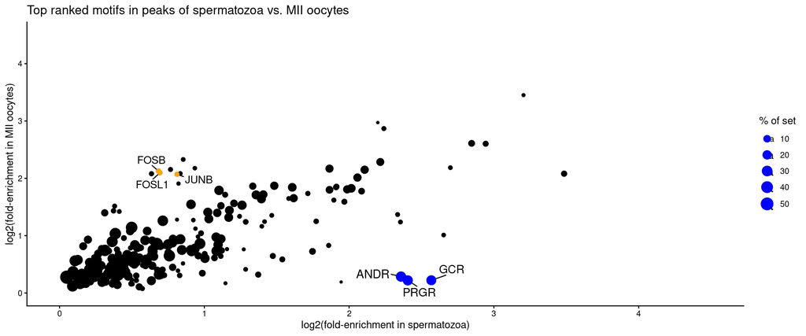

```r
ggplot(m, aes(x=log2((1+tp.sperm)/(1+fp.sperm)), y= log2((1+tp.oocyte)/(1+fp.oocyte)), size=(tp_percent.sperm))) +
  geom_point() +
  geom_text_repel(box.padding=0.5, min.segment.length = 0, max.overlaps = 10, hjust = "left", aes(label=motif_alt), data=m.oo5, size=4) +
  geom_text_repel(box.padding= 0.5, min.segment.length = 0, max.overlaps = 10, hjust = "right", aes(label=motif_alt), data=m.sperm5)+
  geom_point(color="orange", data=m.oo5) +
  geom_point(color="blue", data=m.sperm5) +
  labs(color="Top enriched motifs")+
  labs(x="log2(fold-enrichment in spermatozoa)", y="log2(fold-enrichment in MII oocytes)", size="% of set") +
  xlim(c(0,4.5))+
  ylim(c(0,4.5))+
  #ylab("-log10 (adjusted p-value MII oocyte)")+
  #xlab("-log10 (adjusted p-value spermatozoa)")+
  theme_classic() +
  #theme(legend.position = "none")+
  ggtitle("Top ranked motifs in peaks of spermatozoa vs. MII oocytes")
```

```r
ggsave("./plots/Fig1A_motif_enrichment_sperm_vs_oocyte_peaks_HO11.svg")
ggsave("./plots/Fig1A_motif_enrichment_sperm_vs_oocyte_peaks_HO11.pdf")
ggsave("./plots/Fig1A_motif_enrichment_sperm_vs_oocyte_peaks_HO11.png")
```

# 2 Fig 1B - TF motif activity sperm vs oocyte

```r
core <- read_meme(file = "objects/HOCOMOCOv11_core_MOUSE_mono_meme_format.meme")


# original function PL
summary_core <- universalmotif::summarise_motifs(core)
core <- setNames(object = core,nm = summary_core$name)

motifs <- core
modf <- data.frame(row.names=summary_core$name,
                   TF=gsub("_MOUSE.H11MO...+","",summary_core$name),
                   grade=gsub(".+\\.","",summary_core$name),
                   motif_rank = gsub("[^0123]+","",gsub(".*MO.",replacement = "",summary_core$name))) #gsub("[^ro]+", "", str1)
modf <- modf[order(modf$TF,modf$grade,modf$motif_rank),]
modf <- modf[!duplicated(modf$TF),]
modf <- modf[!modf$grade == "D",]
motifs <- setNames(universalmotif::convert_motifs(motifs[row.names(modf)]), modf$TF)
```

```r
library(TFBSTools)
sc <- readRDS("./objects/sc_sperm_oo.rds")
fa <- Rsamtools::FaFile("objects/Mus_musculus.GRCm39.dna_sm.primary_assembly.fa")

sc_gc <- addGCBias(sc, genome=fa)
motifs <- do.call(what = "PFMatrixList", lapply(motifs, class="TFBSTools-PFMatrix", FUN= convert_motifs))
#motifs <- getNonRedundantMotifs()
motif_ix <- motifmatchr::matchMotifs(motifs, sc_gc, genome=fa)
# motif_ix
# dev <- betterChromVAR::betterChromVAR(object=sc_gc, annotations=motif_ix)


dev <- computeDeviations(object=sc_gc, annotations=motif_ix,background_peaks = getBackgroundPeaks(sc_gc,rowData(sc_gc)$bias,niterations = 5000))
dev$groups <- c("sperm","sperm","MIIoocyte")

fit <- lmFit(assays(dev)$z, model.matrix(~dev$groups))

# dev$groups <- c("sperm","sperm","MIIoocyte")

# fit <- lmFit(assays(dev)$z, model.matrix(~dev$groups),weights=sqrt(rowData(dev)$N)) #background_peaks = getBackgroundPeaks(sc_gc,rowData(sc_gc)$bias,niterations = 5000)
```

```r
ggplot(mores, aes(logFC, -log10(adj.P.Val))) +
  geom_point() +
  geom_hline(yintercept=-log10(0.05), linetype="dashed") +
  ggtitle("Transcription factor motif activity spermatozoa vs MIIoocyte") +
  theme_classic() +
  labs(y = "-log10(adjusted p-value)") +
  geom_text_repel(data = subset(mores, adj.P.Val < 0.01),
                  aes(label = rownames(subset(mores, adj.P.Val < 0.01))),
                  min.segment.length = 0,
                  size = 4)
```

[output not shown]

[output not shown]

```r
#geom_point(aes(color = B)) +

ggsave("./plots/Fig1B_TFmotif_activity_sperm_vs_oocyte_peaks_HO11.svg")
ggsave("./plots/Fig1B_TFmotif_activity_sperm_vs_oocyte_peaks_HO11.pdf")
ggsave("./plots/Fig1B_TFmotif_activity_sperm_vs_oocyte_peaks_HO11.png")
```

# 3 Fig 1C- Sperm GRE peaks across spermatogenesis

action required –> change fig names

```r
tracks <- c(
  uds1="extern_data/ATACse_PRJNA399533_Thy1posSpermatogonia_GSM2751121.bw",
  uds2="extern_data/ATACse_PRJNA399533_Thy1posSpermatogonia_GSM2751122.bw",
  ds1="extern_data/ATACse_PRJNA399533_cKitposSpermatogonia_GSM2751125.bw",
  ds2="extern_data/ATACse_PRJNA399533_cKitposSpermatogonia_GSM2751126.bw",
  ps1="extern_data/ATACse_PRJNA399533_PachytenSpermatocytes_GSM2751129.bw",
  ps2="extern_data/ATACse_PRJNA399533_PachytenSpermatocytes_GSM2751130.bw",
  rs1="extern_data/ATACse_PRJNA399533_RoundSpermatides_GSM2751133.bw",
  rs2="extern_data/ATACse_PRJNA399533_RoundSpermatides_GSM2751134.bw",
  sperm1="extern_data/ATAC_PRJNA480448_Sperm_GSM3262855.bw",
  sperm2="extern_data/ATAC_PRJNA480448_Sperm_GSM3262856.bw",
  sperm3="extern_data/ATAC_PRJNA315208_Sperm_GSM2088377.bw",
  sperm4="extern_data/ATAC_PRJNA315208_Sperm_GSM2088378.bw",
  GVoocyte1="extern_data/ATAC_PRJNA480448_GVOocyte_GSM3262861.bw",
  GVoocyte2="extern_data/ATAC_PRJNA480448_GVOocyte_GSM3262862.bw",
  "MII oocyte"="extern_data/ATAC_PRJNA480448_MIIOocyte_GSM3262863.bw"
)
```

```r
peaks <- readRDS("objects/narrow_peaks_with_GRE_sperm_GCR.HO11.rds")
m <- signal2Matrix(tracks, peaks, w = 20, BPPARAM = 2)
```

[output not shown]

```r
m <- epiwraps:::.ese2ml(m)

fused_uds_mat <- mergeSignalMatrices(m[1:2])
fused_ds_mat <- mergeSignalMatrices(m[3:4])
fused_ps_mat <- mergeSignalMatrices(m[5:6])
fused_rs_mat <- mergeSignalMatrices(m[7:8])
fused_sperm_mat <- mergeSignalMatrices(m[9:12])
fused_gv_mat <- mergeSignalMatrices(m[13:14])

fused_m <- c(list(fused_uds=fused_uds_mat), list(fused_ds=fused_ds_mat), list(fused_ps=fused_ps_mat), list(fused_rs=fused_rs_mat), list(fused_sperm=fused_sperm_mat), list(fused_GVoocytes=fused_gv_mat), m[15], m[-1:-15])
fused_n <- renormalizeBorders(lapply(fused_m,log1p))
```

Combined in one plot

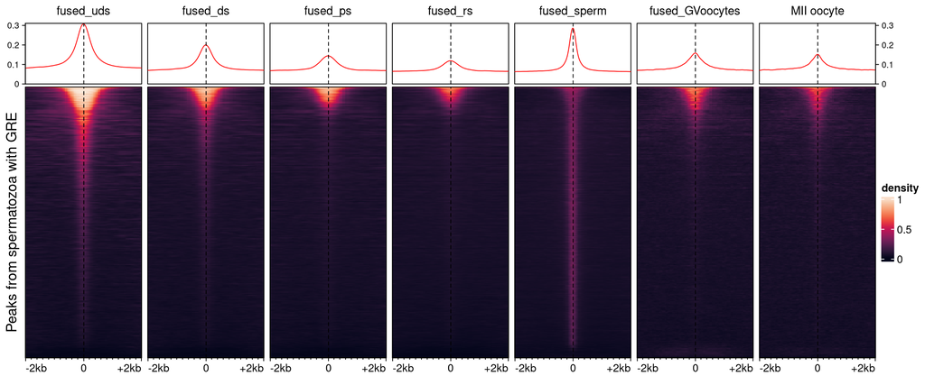

```r
h <- plotEnrichedHeatmaps(fused_n, row_title="Peaks from spermatozoa with GRE", raster_resize_mat = TRUE, axis_name = c("-2kb","0","+2kb"), colors = rocket(2000), mean_color = "#800080")
print(h)
```

```r
pdf("plots/Fig1D_GREpeaks_from_sperm_across_spermatogenesis_normalized_HO11.pdf", width=17.5, height=10)
h <- plotEnrichedHeatmaps(fused_n, row_title="Peaks from spermatozoa with GRE", raster_resize_mat = TRUE, axis_name = c("-2kb","0","+2kb"), colors = rocket(2000), mean_color = "#800080")
print(h)
dev.off()
```

```r
png("plots/Fig1D_GREpeaks_from_sperm_across_spermatogenesis_normalized_HO11.png", height=768)
h <- plotEnrichedHeatmaps(fused_n, row_title="Peaks from spermatozoa with GRE", raster_resize_mat = TRUE, axis_name = c("-2kb","0","+2kb"), colors = rocket(2000), mean_color = "#800080")
print(h)
dev.off()
```

```r
# Create a list of heatmaps
for (i in 1:length(fused_n)) {
  h <- plotEnrichedHeatmaps(fused_n[i], raster_resize_mat = TRUE, axis_name = c("-2kb","0","+2kb"), colors = rocket(2000), mean_color = "#800080",
                            heatmap_legend_param = list(legend_direction = "horizontal", legend_width = unit(0.28, "npc"), title=NULL))

  # Save each heatmap to a PDF
  pdf(paste0("plots/Fig1D_GREpeaks_from_sperm_across_spermatogenesis_normalized_", i, "_HO11",".pdf"), width=2.5, height=10)
  draw(h, heatmap_legend_side="bottom", annotation_legend_side="right",  legend_grouping = "original")
  dev.off()
}
```

```r
# Create a list of heatmaps
for (i in 1:length(fused_n)) {
  h <- plotEnrichedHeatmaps(fused_n[i], raster_resize_mat = TRUE, axis_name = c("-2kb","0","+2kb"), colors = rocket(2000), mean_color = "#800080",
                            heatmap_legend_param = list(legend_direction = "horizontal", legend_width = unit(0.4, "npc"), title=NULL))

  # Save each heatmap to a PNG
  png(paste0("plots/Fig1D_GREpeaks_from_sperm_across_spermatogenesis_normalized_", i,"_HO11", ".png"), width=250, height=768)
  draw(h, heatmap_legend_side="bottom", annotation_legend_side="right",  legend_grouping = "original")
  dev.off()
}
```

# 4 Fig 1E - GR-ChIP

action required!

```r
bw <- list.files(path = "intern_data/ChIP/",pattern = "*.bw$",full.names = T)
names(bw) <- basename(bw)

bw <- bw[!grepl(pattern = "Input|Stress",bw)]




GR_bed <- sapply(names(bw),function(names){
  import.bw(bw[names])
})
```

import peaks

```r
se <- readRDS("intern_data/ChIP/GR_counts_non_resized.SE.rds")


GRpeaks <- granges(se)
```

```r
sm_GR <-  signal2Matrix(filepaths = GR_bed,regions = GRpeaks,w = 10L,smooth = T, background= 0)
sm_merge_GR <- mergeSignalMatrices(epiwraps:::.ese2ml(sm_GR))
```

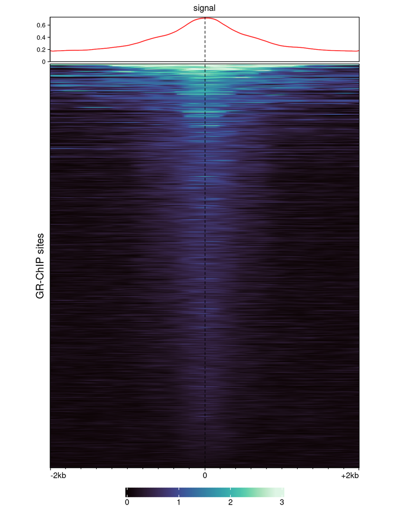

```r
p_GR1 <-  plotEnrichedHeatmaps(sm_merge_GR,row_title = "GR-ChIP sites",scale_title = "GR\ndesnity",colors = mako(2000), raster_resize_mat = TRUE, use_raster = TRUE,axis_name = c("-2kb","0","+2kb"), trim = c(0.01,0.99),width = unit(0.8,"npc"), heatmap_legend_param = list(legend_direction = "horizontal", legend_width = unit(0.4,"npc"), title=NULL))



  draw(p_GR1, heatmap_legend_side="bottom", annotation_legend_side="right",  legend_grouping = "original")
```

```r
  png(paste0("plots/Fig1F.png"), width=250, height=768)
  draw(p_GR1, heatmap_legend_side="bottom", annotation_legend_side="right",  legend_grouping = "original")
  dev.off()
```

```r
  pdf(paste0("plots/Fig1F.pdf"), width=2.5, height=10)
  draw(p_GR1, heatmap_legend_side="bottom", annotation_legend_side="right",  legend_grouping = "original")
  dev.off()
```

```r
  svg(paste0("plots/Fig1F.svg"), width=2.5, height=10)
  draw(p_GR1, heatmap_legend_side="bottom", annotation_legend_side="right",  legend_grouping = "original")
  dev.off()
```

# 5 Fig 1F GR-ChIP GO:BP overrepresentation analysis

action required

```r
library(clusterProfiler)
library(org.Mm.eg.db)
```

```r
se <- readRDS("intern_data/ChIP/GR_counts_non_resized.SE.rds")
ah <- AnnotationHub()
genome <- ah[["AH89457"]]

annGR <- transcripts(genome,
 columns = c("tx_id", "tx_biotype", "gene_id", "gene_name")
)


anno_Stress <- ChIPpeakAnno::annoPeaks(peaks = granges(se),annoData = annGR,bindingType = "fullRange",select = "bestOne")

# table(width(peaks)<=500)
```

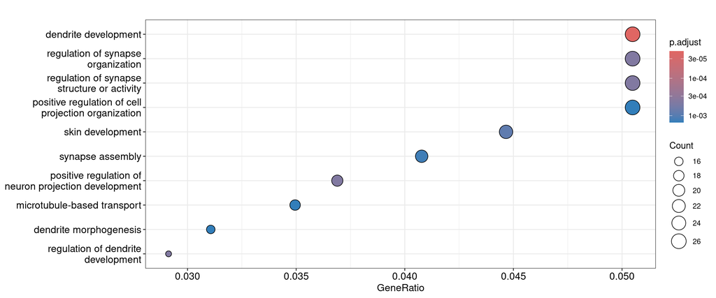

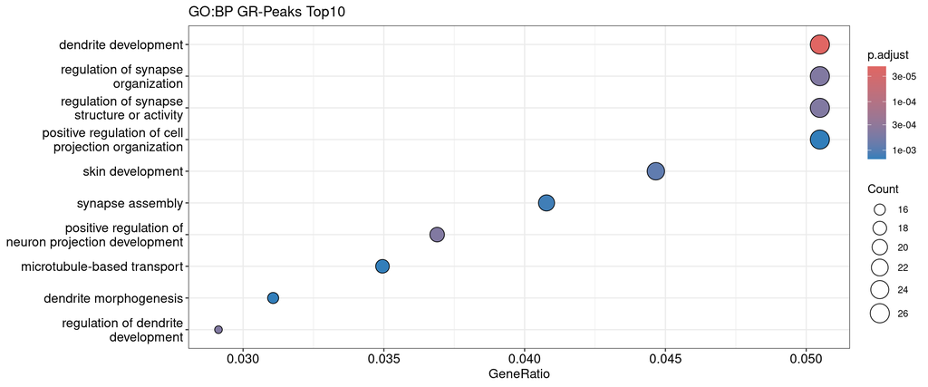

```r
set.seed(123)


  gene_list <- unlist(anno_Stress$gene_name)
  gene_list <- gene_list[!duplicated(gene_list)]

kegg <- enrichGO(gene          = gene_list,
                OrgDb         = org.Mm.eg.db,
                keyType       = "SYMBOL",
                ont           = "BP",  # BP: Biological Process, MF: Molecular Function, CC: Cellular Component
                pAdjustMethod = "BH",
                pvalueCutoff  = 1,
                qvalueCutoff  = 1

                    )





d <- dotplot(kegg, showCategory=10)
print(d)+ggtitle("GO:BP GR-Peaks Top10")
```

```r
# kegg@result
ggsave("plots/Fig1F_GOBP_GRChIP.png")
ggsave("plots/Fig1F_GOBP_GRChIP.pdf")
#kegg@result
```

## 5.1 Fig S1A - Comparison sperm data of published data and of Fischer and Kretschmer 2023

```r
peaks <- readRDS("objects/consensus.peaks_sperm.rds")
# GenomeInfoDb::seqinfo(peaks) <- "mm39"
tracks <- c(
  "Jung 1"="extern_data//ATAC_PRJNA480448_Sperm_GSM3262855.bw",
  "Jung 2"="extern_data//ATAC_PRJNA480448_Sperm_GSM3262856.bw",
  "Jung 3"="extern_data//ATAC_PRJNA315208_Sperm_GSM2088377.bw",
  "Jung 4"="extern_data//ATAC_PRJNA315208_Sperm_GSM2088378.bw",
  "Fischer 1"="extern_data/NoMx_N704_KG.bw",
  "Fischer 2"="extern_data/NoMx_N705_KG.bw"
)

m <- signal2Matrix(tracks, peaks, w = 20, BPPARAM = 4)
```

[output not shown]

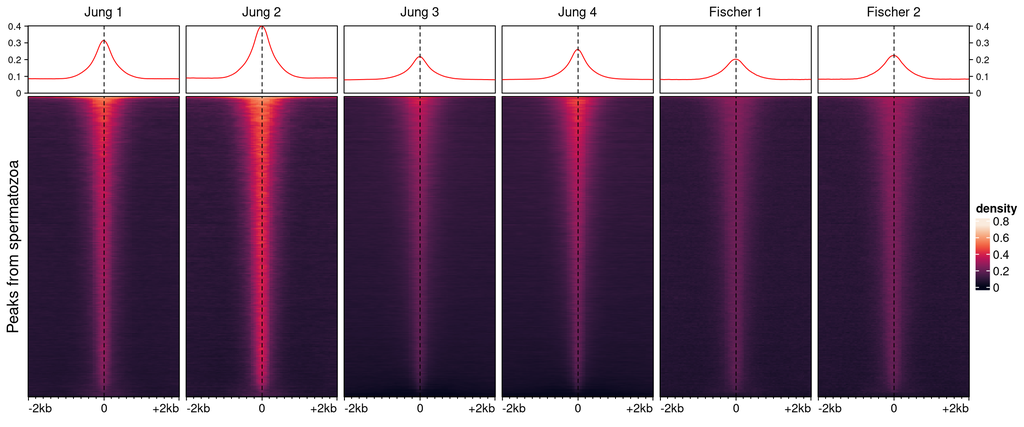

```r
m <- epiwraps:::.ese2ml(m)
n <- renormalizeBorders(lapply(m,log1p))


h <- plotEnrichedHeatmaps(n, row_title="Peaks from spermatozoa", raster_resize_mat = TRUE, axis_name = c("-2kb","0","+2kb"), colors = rocket(2000), mean_trim = TRUE)
print(h)
```

```r
dev.off()
```

```r
  pdf("sup_plots/FigS1A_sperm_comparisons.pdf", width=17.5, height=10)
h <- plotEnrichedHeatmaps(n, row_title="Peaks from spermatozoa", raster_resize_mat = TRUE, axis_name = c("-2kb","0","+2kb"), colors = rocket(2000), mean_trim = TRUE)
print(h)
dev.off()
```

```r
png("sup_plots/FigS1A_sperm_comparisons.png", height=768)
h <- plotEnrichedHeatmaps(n, row_title="Peaks from spermatozoa", raster_resize_mat = TRUE, axis_name = c("-2kb","0","+2kb"), colors = rocket(2000), mean_color = "#800080")
print(h)
dev.off()
```

## 5.2 Fig S1B A549 atac motif enrichment

sperm vs A549 enrichment

```r
d.sperm <- readRDS("objects/motif_enrichment_sperm_consensus_narrow_HO11.rds")
d.a549 <- readRDS("objects/motif_enrichment_sperm_A549_HO11.rds")
# m <- merge(d.a549, d.sperm, by="motif_id", suffixes=c(".a549",".sperm"))
#
# m.a549.sort <- m[order(m[,2],decreasing = FALSE),]
# m.a5495 <- m.a549.sort[1:3,]
# m.sperm.sort <- m[order(m[,18],decreasing = FALSE),]
# m.sperm5 <- m.sperm.sort[1:3,]
# # m




m <- merge(d.a549, d.sperm, by="motif_id", suffixes=c(".a549",".sperm"))

m.a549.sort <- m[order(m[,2],decreasing = FALSE),]
m.a5495 <- m.oo.sort[1:3,]
m.a5495$motif_alt <- gsub(x = m.a5495$motif_id,pattern = "\\_MOUSE.H11(.*)",replacement = "")

m.sperm.sort <- m[order(m[,18],decreasing = FALSE),]
m.sperm5 <- m.sperm.sort[1:3,]
m.sperm5$motif_alt <- gsub(x = m.sperm5$motif_id,pattern = "\\_MOUSE.H11(.*)",replacement = "")

m$motif_alt <- gsub(x = m$motif_id,pattern = "\\_MOUSE.H11(.*)",replacement = "")

gr <- m.sperm.sort[2, ]
gr$motif_alt <- gsub(x = gr$motif_id,pattern = "\\_MOUSE.H11(.*)",replacement = "")
stat1 <- m.a549.sort[2, ]
stat1$motif_alt <- gsub(x = stat1$motif_id,pattern = "\\_MOUSE.H11(.*)",replacement = "")
```

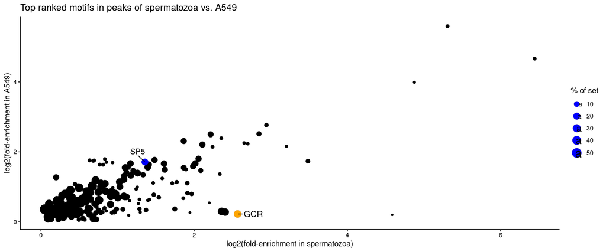

```r
ggplot(m, aes(x=log2((1+tp.sperm)/(1+fp.sperm)), y= log2((1+tp.a549)/(1+fp.a549)), size=(tp_percent.sperm))) +
  geom_point() +

  geom_point(data=gr, color="orange")+
  geom_text_repel(box.padding=0.5, min.segment.length = 0, max.overlaps = 10,  nudge_x = 0.3, direction = "x", hjust = "right", aes(label=motif_alt ), data= gr)+
  geom_point(data=stat1, color="blue")+
  geom_text_repel(box.padding=0.5, min.segment.length = 0, max.overlaps = 10,  nudge_y = 0.3, direction = "y", hjust = "right", aes(label=motif_alt ), data= stat1)+

  labs(color="Top enriched motifs")+
  labs(x="log2(fold-enrichment in spermatozoa)", y="log2(fold-enrichment in A549)", size="% of set") +

  theme_classic() +

  ggtitle("Top ranked motifs in peaks of spermatozoa vs. A549")
```

```r
ggsave("./sup_plots/FigS1B_motif_enrichment_sperm_vs_A549_peaks_HO11.svg")
ggsave("./sup_plots/FigS1B_motif_enrichment_sperm_vs_A549_peaks_HO11.pdf")
ggsave("./sup_plots/FigS1B_motif_enrichment_sperm_vs_A549_peaks_HO11.png")
```

## 5.3 Fig S1C - Sperm GRE peaks not accessible in immature germ cells across spermatogenesis

```r
tracks <- c(
  uds1="extern_data/ATACse_PRJNA399533_Thy1posSpermatogonia_GSM2751121.bw",
  uds2="extern_data/ATACse_PRJNA399533_Thy1posSpermatogonia_GSM2751122.bw",
  ds1="extern_data/ATACse_PRJNA399533_cKitposSpermatogonia_GSM2751125.bw",
  ds2="extern_data/ATACse_PRJNA399533_cKitposSpermatogonia_GSM2751126.bw",
  ps1="extern_data/ATACse_PRJNA399533_PachytenSpermatocytes_GSM2751129.bw",
  ps2="extern_data/ATACse_PRJNA399533_PachytenSpermatocytes_GSM2751130.bw",
  rs1="extern_data/ATACse_PRJNA399533_RoundSpermatides_GSM2751133.bw",
  rs2="extern_data/ATACse_PRJNA399533_RoundSpermatides_GSM2751134.bw",
  sperm1="extern_data/ATAC_PRJNA480448_Sperm_GSM3262855.bw",
  sperm2="extern_data/ATAC_PRJNA480448_Sperm_GSM3262856.bw",
  sperm3="extern_data/ATAC_PRJNA315208_Sperm_GSM2088377.bw",
  sperm4="extern_data/ATAC_PRJNA315208_Sperm_GSM2088378.bw",
  GVoocyte1="extern_data/ATAC_PRJNA480448_GVOocyte_GSM3262861.bw",
  GVoocyte2="extern_data/ATAC_PRJNA480448_GVOocyte_GSM3262862.bw",
  "MII oocyte"="extern_data/ATAC_PRJNA480448_MIIOocyte_GSM3262863.bw"
)
```

```r
peaks <- readRDS("./objects/narrow_overlaps_spermGRE_not_immatureGermCellsGRE_GCR.HO11.rds")
m <- signal2Matrix(tracks, peaks, w = 20, BPPARAM = 2)
```

[output not shown]

```r
m <- epiwraps:::.ese2ml(m)

fused_uds_mat <- mergeSignalMatrices(m[1:2])
fused_ds_mat <- mergeSignalMatrices(m[3:4])
fused_ps_mat <- mergeSignalMatrices(m[5:6])
fused_rs_mat <- mergeSignalMatrices(m[7:8])
fused_sperm_mat <- mergeSignalMatrices(m[9:12])
fused_gv_mat <- mergeSignalMatrices(m[13:14])

fused_m <- c(list(fused_uds=fused_uds_mat), list(fused_ds=fused_ds_mat), list(fused_ps=fused_ps_mat), list(fused_rs=fused_rs_mat), list(fused_sperm=fused_sperm_mat), list(fused_GVoocytes=fused_gv_mat), m[15], m[-1:-15])
fused_n <- renormalizeBorders(lapply(fused_m,log1p))
```

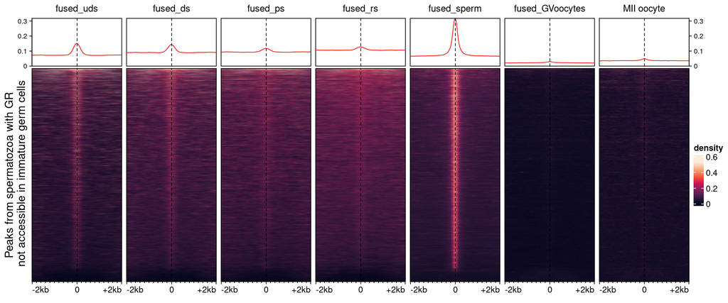

```r
h <- plotEnrichedHeatmaps(fused_m, row_title="Peaks from spermatozoa with GR\n not accessible in immature germ cells", raster_resize_mat = FALSE, axis_name = c("-2kb","0","+2kb"), colors = rocket(2000), mean_color = "#800080")
print(h)
```

```r
pdf("plots/FigS1C_GREpeaks_from_sperm_notimmature_across_spermatogenesis_HO11.pdf", width=17.5, height=10)
h <- plotEnrichedHeatmaps(fused_m, row_title="Peaks from spermatozoa with GR\n not accessible in immature germ cells", raster_resize_mat = FALSE, axis_name = c("-2kb","0","+2kb"), colors = rocket(2000), mean_color = "#800080")
print(h)
dev.off()
```

```r
png("plots/FigS1C_GREpeaks_from_sperm_notimmature_across_spermatogenesis_HO11.png", height=768)
h <- plotEnrichedHeatmaps(fused_m, row_title="Peaks from spermatozoa with GR\n not accessible in immature germ cells", raster_resize_mat = TRUE, axis_name = c("-2kb","0","+2kb"), colors = rocket(2000), mean_color = "#800080")
print(h)
dev.off()
```

# 6 Fig 2C GR-CUT&Tag signal waterfall

```r
peaks <- readRDS(file = "intern_data/GR_CUTnTag/GRCUTNTag_e2c.rds")
peaks <- GenomeInfoDb::keepStandardChromosomes(peaks,pruning.mode = "coarse")
```

list tracks

```r
bw_list <- list.files(path = "intern_data/GR_CUTnTag/",pattern = ".bw$",full.names = T)
names <- gsub(x = basename(bw_list),pattern = "\\.bam|.bw",replacement = "")
names(bw_list) <- names

bw_GR <- bw_list
bw_GR_full <- bw_GR[grepl(x = names(bw_GR),pattern = "full")]
# bw_GR_full <- bw_GR_full[1:2]
```

```r
sm_embryo <- signal2Matrix(w = 20L, filepaths = bw_GR_full,regions = peaks,smooth = T, background= 0)
colnames(sm_embryo) <- c("Rep.1","Rep.2", "Rep.3", "Rep.4")
```

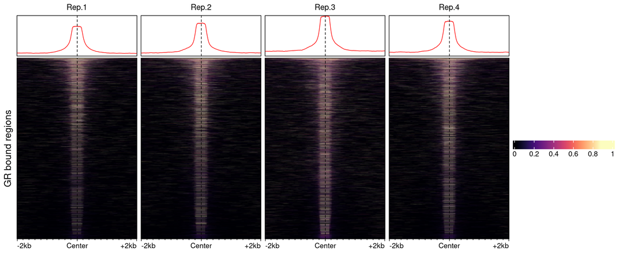

```r
p <- plotEnrichedHeatmaps(ml = sm_embryo,use_raster = T,row_title = paste0("GR bound regions") ,scale_title = "Embryo\ndensity",colors = magma(2000),mean_scale_side = "none",axis_name = c("-2kb","Center","+2kb"),trim = c(0.1,0.95), heatmap_legend_param = list(legend_direction = "horizontal", legend_width = unit(0.28, "npc"), title=NULL),scale_rows = FALSE)
p
```

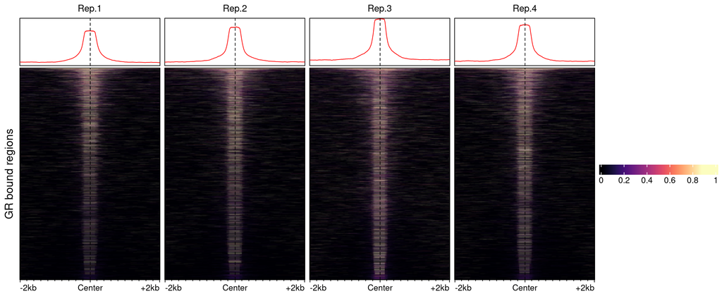

```r
 print(p)
```

```r
  png(paste0("plots/","Fig2C_Heatmap_GR_embryo",".png"), width=500, height=50)
  draw(p, heatmap_legend_side="bottom", annotation_legend_side="right",  legend_grouping = "original")
  dev.off()
```

```r
  pdf(paste0("plots/","Fig2C_Heatmap_GR_embryo",".pdf"), width=5, height=5)
  draw(p, heatmap_legend_side="bottom", annotation_legend_side="right",  legend_grouping = "original")
  dev.off()
```

```r
  svg(paste0("plots/","Fig2C_Heatmap_GR_embryo",".svg"), width=5, height=5)
  draw(p, heatmap_legend_side="bottom", annotation_legend_side="right",  legend_grouping = "original")
  dev.off()
```

# 7 Fig 2F 2cellEmbryo Treatment effect of KH103 volcano

action required!

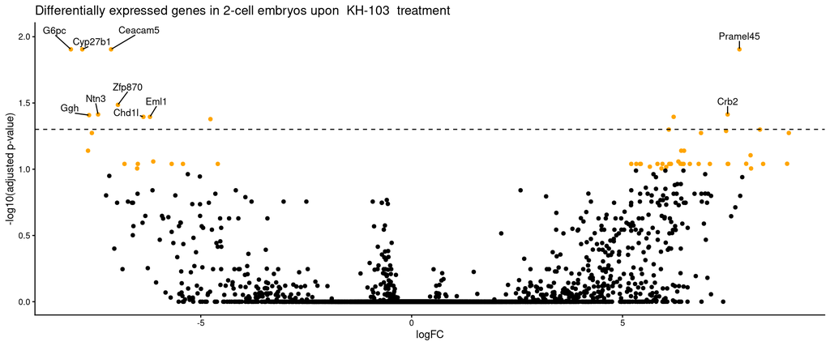

```r
se <- readRDS("objects/MK_EXP20.1_ProtacEmbryo_merged.SE.rds")

protac <- rowData(se)[[3]]



protac$Gene <- rownames(protac)


# List of dataframes
df_list <- list("KH-103" = protac)

# Function to generate volcano plots
generate_volcano_plot <- function(df, title) {
  df$highlight <- df$FDR < 0.1
  top_genes <- df[order(df$FDR), ][1:10, ]
  ggplot(df, aes(x=logFC, y=-log10(FDR))) +
    geom_point(aes(color = highlight)) +
    scale_color_manual(values = c("TRUE" = "orange", "FALSE" = "black")) +
    geom_text_repel(data = subset(top_genes, highlight == TRUE), aes(label=Gene), size=3.5, min.segment.length = 0, max.overlaps = Inf, nudge_y = 0.1) +
    geom_hline(yintercept=-log10(0.05), linetype="dashed")+
    xlab("logFC") +
    ylab("-log10(adjusted p-value)") +
    theme_classic() +
    theme(legend.position="none") +
    ggtitle(title)
}

# Apply the function to each dataframe in the list
plots <- lapply(names(df_list), function(name) {
  generate_volcano_plot(df_list[[name]], paste("Differentially expressed genes in 2-cell embryos upon ", name, " treatment"))
})

print(plots)
```

```r
# openxlsx::write.xlsx(protac,file = "objects/DEA_e2c_KH103.xlsx",rowNames = T)
```

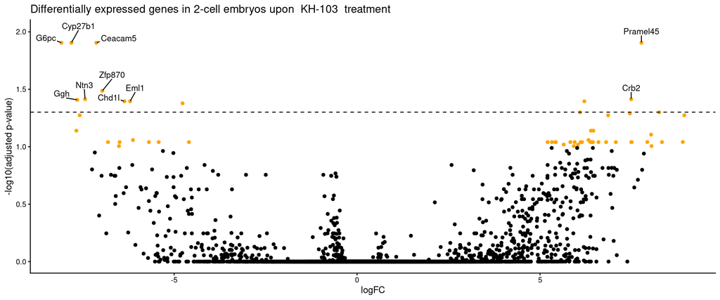

```r
print(plots)
```

```r
ggsave("plots/Fig2F_DEGs_2cellEmbryo_KH103.svg")
ggsave("plots/Fig2F_DEGs_2cellEmbryo_KH103.pdf")
ggsave("plots/Fig2F_DEGs_2cellEmbryo_KH103.png")
```

### 7.0.1 Affected genes overlap with GR-CuTnTag

```r
proms <- granges(readRDS("intern_data/GR_CUTnTag//GRCUTNTag_e2c.rds"))

proms <- GenomeInfoDb::keepStandardChromosomes((proms),pruning.mode = "coarse")
ah <- AnnotationHub()
ensdb <- ah[["AH89457"]]
ensdb <- GenomeInfoDb::keepStandardChromosomes(transcripts(ensdb,columns = c("tx_id", "gene_id", "gene_name")),pruning.mode = "coarse")

seqlevels(proms) <- seqlevels(ensdb)
seqinfo(proms) <- seqinfo(ensdb)
```

```r
proms10 <- proms
```

```r
chain <- "objects/mm39ToMm10.over.chain"
bfc <- BiocFileCache()
if(nrow(bfcquery(bfc, basename(chain)))==0){bfcadd(bfc, chain)}


    seqlevelsStyle(proms10) <-"UCSC"
  genome(proms10) <- "mm39"
  proms10 <- easylift::easylift(proms10, "mm10")
  # seqlevelsStyle(proms10) <-"Ensembl"
  #
  # genome(proms10) <- "GRCm38"
```

```r
library(rGREAT)

gt <- great(
    proms10,
    gene_sets = "GO:BP",
    tss_source = "TxDb.Mmusculus.UCSC.mm10.knownGene"
)

# Peak-to-gene associations
assoc <- getRegionGeneAssociations(gt)
```

```r
se2 <- readRDS("objects/MK_EXP20.1_ProtacEmbryo_merged_2.SE.rds")
```

```r
x <- table(unlist(assoc$annotated_genes)[unlist(assoc$annotated_genes) %in% rownames(protac[protac$FDR < 0.1,])])
n <- nrow(protac[protac$FDR < 0.1,])
p <- length(table(unlist(assoc$annotated_genes)[unlist(assoc$annotated_genes) %in% rownames(se2)]))/nrow(se2)
binom.test(x = length(x),n = n,p = p,alternative = "greater")
```

```
##
##  Exact binomial test
##
## data:  length(x) and n
## number of successes = 17, number of trials = 53, p-value = 0.03807
## alternative hypothesis: true probability of success is greater than 0.2089104
## 95 percent confidence interval:
##  0.2157607 1.0000000
## sample estimates:
## probability of success
##              0.3207547
```

# 8 Fig 2G 8cellEmbryo Treatment effect of KH103 heatmap

action required

```r
se <- readRDS("objects/MK_EXP20.2_ProtacEmbryo8cells.SE.rds")
se <- se[, se$treatment != "DEXR"]
se <- se[, se$treatment != "DEX"]
se <- se[, se$treatment != "PDR"]
se <- se[, se$treatment != "PD"]

# Generate the dataframes
protac <- rowData(se)[[3]]
protac$Gene <- rownames(protac)
protacFDR <- subset(protac, protac$adj.P.Val <0.1)


treatments <- unique(se$treatment)

# Define own colors
colors <- c("#DEDFE4", "darkgrey") # "#919297", "#393A3F",)# , "#800080", "black", "yellow", "orange")#232429"

# Make sure the number of colors matches the number of treatments
if (length(colors) != length(treatments)) {
  stop("Number of colors must match number of treatments")
}

# Create a named vector for color mapping
color_mapping <- setNames(colors, treatments)

# Add color_mapping to the heatmap annotation
ha = HeatmapAnnotation(df = data.frame(treatment = factor(colData(se)$treatment, levels = names(color_mapping))),
                       col = list(treatment = color_mapping))

color_palette <- colorRampPalette(c("blue", "black", "orange"))(101)

pdf("plots/Fig3E_DEGs_EXP20-2_PROTAC_heatmap.pdf") #, width=14.5, height=10)
x <- sechm(se, protacFDR, assayName = "log2FC", do.scale = FALSE, top_annotation = ha, row_title="Differentially expressed genes", gaps_at="treatment", hmcols = color_palette, use_raster = TRUE)
print(x)
dev.off()
```

```r
png("plots/Fig3E_DEGs_EXP20-2_PROTAC_heatmap.png", height=768)
x <- sechm(se, protacFDR, assayName = "log2FC", do.scale = FALSE, top_annotation = ha, row_title="Differentially expressed genes", gaps_at="treatment", hmcols = color_palette, use_raster = TRUE)
print(x)
dev.off()
```

```r
#needs title : KH-103 effects on gene regulation in 8-cell embryos

svg("plots/Fig3E_DEGs_EXP20-2_PROTAC_heatmap.svg")
x <- sechm(se, protacFDR, assayName = "log2FC", do.scale = FALSE, top_annotation = ha, row_title="Differentially expressed genes", gaps_at="treatment", hmcols = color_palette, use_raster = TRUE)
print(x)
dev.off()
```

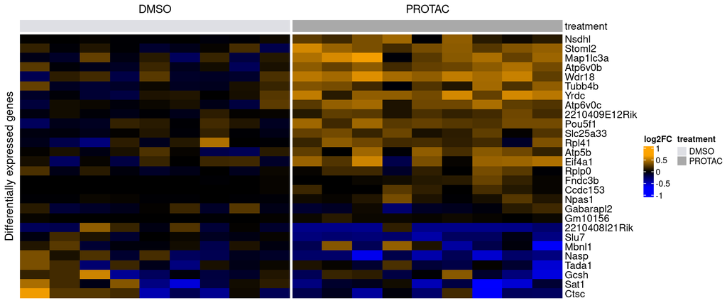

```r
sechm(se, protacFDR, assayName = "log2FC", do.scale = FALSE, top_annotation = ha, row_title="Differentially expressed genes", gaps_at="treatment", hmcols = color_palette, use_raster = TRUE)
```

## 8.1 Fig S2D Motif Enrichment GR-CUT&Tag in 2cellEmbryo

motifs

```r
core <- read_meme(file = "objects/HOCOMOCOv11_core_MOUSE_mono_meme_format.meme")
#full <- read_meme(file = "HOCOMOCOv11_full_MOUSE_mono_meme_format.meme")


# original function PL
summary_core <- universalmotif::summarise_motifs(core)
core <- setNames(object = core,nm = summary_core$name)

motifs <- core
modf <- data.frame(row.names=summary_core$name,
                     TF=gsub("_MOUSE.H11MO...+","",summary_core$name),
                     grade=gsub(".+\\.","",summary_core$name),
                     motif_rank = gsub("[^0123]+","",gsub(".*MO.",replacement = "",summary_core$name))) #gsub("[^ro]+", "", str1)
modf <- modf[order(modf$TF,modf$grade,modf$motif_rank),]
modf <- modf[!duplicated(modf$TF),]
modf <- modf[!modf$grade == "D",]
motifs <- setNames(universalmotif::convert_motifs(motifs[row.names(modf)]), modf$TF)
```

genome

```r
genome <- Rsamtools::FaFile("objects/Mus_musculus.GRCm39.dna_sm.primary_assembly.fa")
```

```r
merge_narrow_threshold_0.05 <- readRDS("intern_data/GR_CUTnTag/GRCUTNTag_e2c.rds")
merge_narrow_threshold_0.05 <-  resize(merge_narrow_threshold_0.05,width = 200,fix = "center")
gr <- granges(merge_narrow_threshold_0.05)
```

```r
peak_centers <- gr # appx median of consensus opeaks
peak_centers <- GenomeInfoDb::keepStandardChromosomes(peak_centers,pruning.mode = "coarse")
peak_seqs <- memes::get_sequence(GenomeInfoDb::dropSeqlevels(peak_centers,"MT",pruning.mode = "coarse"), genome)# dropping MT due to its absence in  reference genome file

ame_merge_narrow_threshold_0.05<- runAme(peak_seqs , database=convert_motifs(motifs), meme_path="/common/meme/bin/")
```

```r
ame_merge_narrow_threshold_0.05$motif <- basename(ame_merge_narrow_threshold_0.05$motif_db)
```

```r
# ame_merge_narrow_threshold_0.05[ame_merge_narrow_threshold_0.05$motif_id]
```

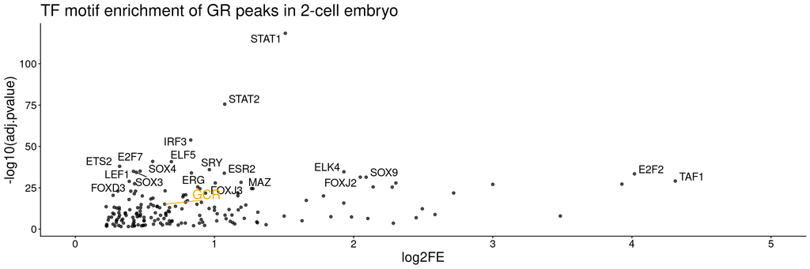

```r
p2 <- ggplot(ame_merge_narrow_threshold_0.05, aes(log2(((tp/pos))/((fp/neg))), -log10(adj.pvalue))) +
  geom_point(alpha=0.7, size =1.5) + geom_text_repel(data=head((ame_merge_narrow_threshold_0.05),20), aes(label=motif),max.overlaps = 20, size = 5)+
  labs(x="log2FE")+ xlim(c(0,5))+theme(text = element_text(size = 13))+ggtitle("TF motif enrichment of GR peaks in 2-cell embryo")+
      geom_text_repel(data=ame_merge_narrow_threshold_0.05[(ame_merge_narrow_threshold_0.05$motif == "GCR"),],colour = "orange", aes(label=motif),max.overlaps = 20, size = 6,nudge_x = 0.3,nudge_y = 6)+
    # geom_text_repel(data=ame_merge_narrow_threshold_0.05[(ame_merge_narrow_threshold_0.05$motif == "ANDR"),], aes(label=motif),max.overlaps = 20, size = 4)+
    # geom_text_repel(data=ame_merge_narrow_threshold_0.05[(ame_merge_narrow_threshold_0.05$motif == "PRGR"),], aes(label=motif),max.overlaps = 20, size = 4)+
  theme_classic() +
  theme(legend.position = "none",axis.text.x = element_text(size=14),
          axis.text.y = element_text(size=14),
          legend.text = element_text(size=12),
          legend.title = element_text(size = 14),
          text = element_text(size = 18)
    )
p2
```

```r
ggsave("sup_plots/FigS2D_motifEnrichemnt_GR_embryo.svg")
ggsave("sup_plots/FigS2D_motifEnrichemnt_GR_embryo.png")
ggsave("sup_plots/FigS2D_motifEnrichemnt_GR_embryo.pdf")
```

## 8.2 Fig S2E GO:BP overrepresentation GR-CUT&Tag in 2cellEmbryo

```r
poi <- readRDS("intern_data/GR_CUTnTag/GRCUTNTag_e2c.rds")
```

```r
ah <- AnnotationHub()
genome <- ah[["AH89457"]]

annGR <- transcripts(genome,
 columns = c("tx_id", "tx_biotype", "gene_id", "gene_name")
)

poi_annotated <- ChIPpeakAnno::annoPeaks(peaks = poi,annoData = annGR,bindingType = "fullRange",select = "bestOne")
```

```r
set.seed(123)


  gene_list <- unlist(poi_annotated$gene_name)
  gene_list <- gene_list[!duplicated(gene_list)]

gobp <- enrichGO(gene          = gene_list,
                OrgDb         = org.Mm.eg.db,
                keyType       = "SYMBOL",
                ont           = "BP",  # BP: Biological Process, MF: Molecular Function, CC: Cellular Component
                pAdjustMethod = "BH",
                pvalueCutoff  = 1,
                qvalueCutoff  = 1
)

# d <- dotplot(gobp, showCategory=10)
# print(d)
# gobp@result
```

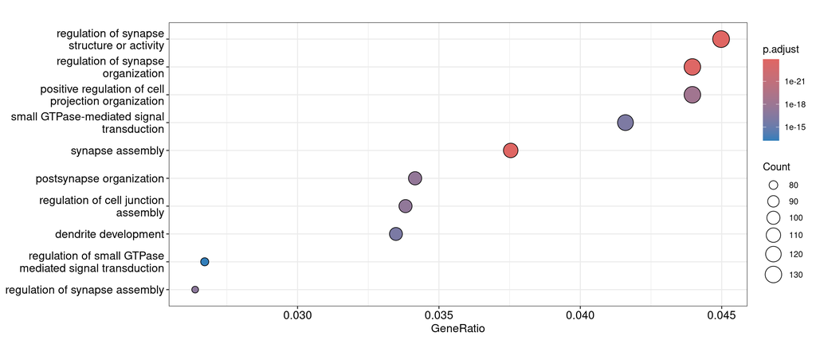

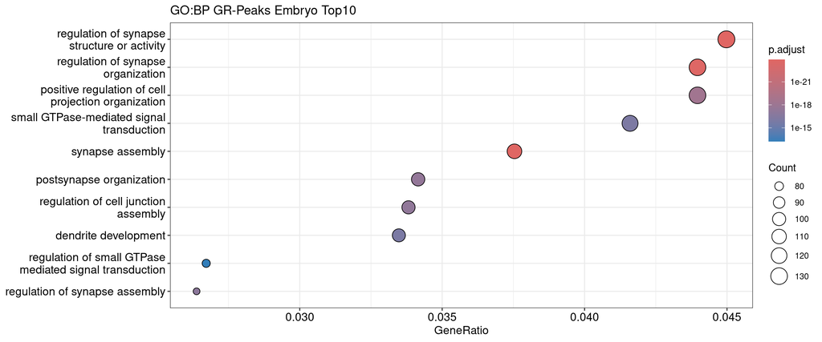

```r
d <- dotplot(gobp, showCategory=10)

print(d)+ggtitle("GO:BP GR-Peaks Embryo Top10")
```

```r
# kegg@result
ggsave("sup_plots/FigS2E_GOBP_e2c_CnT.png")
ggsave("sup_plots/FigS2E_GOBP_e2c_CnT.pdf")
```

# 9 Fig 3B Cort in IFS animals

```r
df <- openxlsx::read.xlsx("objects/PostIFS20min.xlsx")
df$Condition <- factor(df$Condition,levels = c("CTRL","IFS"),labels = c("Control","Stress"))
```

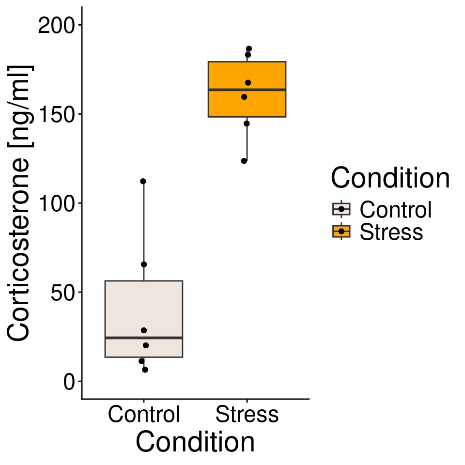

```r
e <- ggplot(df, aes(x = Condition, y = df$`ng/mL`, fill = Condition))


 e2 <- e + geom_boxplot(width = 0.75,outlier.shape = NA ) +
   geom_jitter(
   position=position_jitterdodge(jitter.width = 0.1, dodge.width = 0.75)
    )+
    ylab("Corticosterone [ng/ml]")+
   xlab("Condition")+
   # ggtitle("Baseline Cort. after Stress")+
   scale_fill_manual(values=c( "seashell2","#ffa500ff"))+
   labs(fill= "Condition")+
    ylim(c(0,200))+
   theme_classic()+

 theme(
  # axis.text.x = element_text(size = 13),
  text = element_text(size = 22)
)


 print(e2)
```

```r
t.test(df$`ng/mL` ~Condition, data = df, alternative = "two.sided")
```

```
##
##  Welch Two Sample t-test
##
## data:  df$`ng/mL` by Condition
## t = -6.2186, df = 8.0671, p-value = 0.0002456
## alternative hypothesis: true difference in means between group Control and group Stress is not equal to 0
## 95 percent confidence interval:
##  -164.66081  -75.66979
## sample estimates:
## mean in group Control  mean in group Stress
##              40.72068             160.88598
```

```r
shapiro.test(df$`ng/mL`[df$Condition == "Control"])
```

```
##
##  Shapiro-Wilk normality test
##
## data:  df$`ng/mL`[df$Condition == "Control"]
## W = 0.84565, p-value = 0.1451
```

```r
wilcox.test(df$`ng/mL` ~Condition, data = df, alternative = "two.sided")
```

```
##
##  Wilcoxon rank sum exact test
##
## data:  df$`ng/mL` by Condition
## W = 0, p-value = 0.002165
## alternative hypothesis: true location shift is not equal to 0
```

```r
ggsave("plots/Fig3B_StressedAnimalsBaselineCort20min.png")
ggsave("plots/Fig3B_StressedAnimalsBaselineCort20min.pdf")
    # ggsave("plots/Fig5C.StressedAnimalsBaselineCort.svg")
```

# 10 Fig 3C UMAP of Transition in IFS animals

action required

```r
set.seed(123)
US <- readRDS("objects/US_object_IFS_OFT1.rds")

US <- TwoGroupAnalysis(US, group = US$meta$Stress)
US <- TwoGroupAnalysis_Clusters(US, group = US$meta$Stress)

  x <- Plot2DEmbedding(US, report = US$label_names[2], colorby = "condition", color = c("seashell3", "#ffa500ff"), plot.sem = T)+ ggtitle(paste0("UMAP of IFS animal cluster transitions"))
```

```
## [1] "including report: kmeans.50"
```

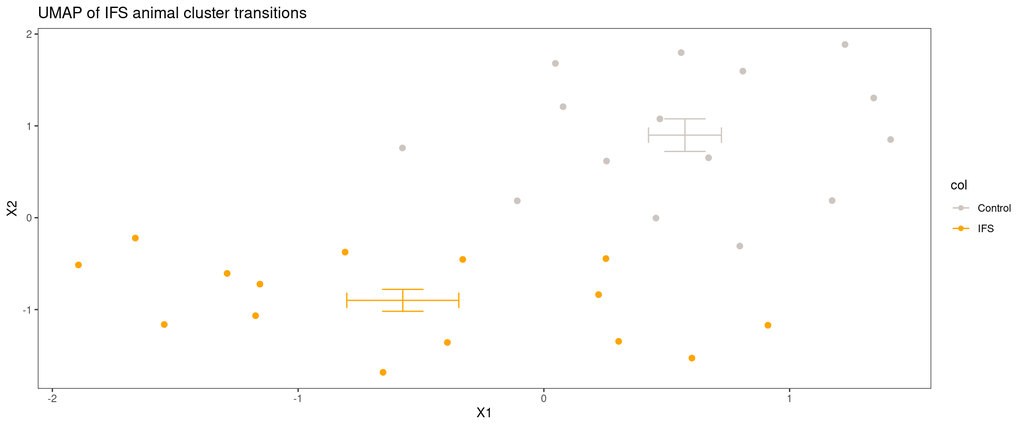

```r
  print(x)
```

```r
  ggsave("sup_plots/Fig3C_father_OFT1_2D.pdf")
  ggsave("sup_plots/Fig3C_father_OFT1_2D.png")
  ggsave("sup_plots/Fig3C_father_OFT1_2D.svg")
```

# 11 Fig 3D BFA of IFS animals

action required

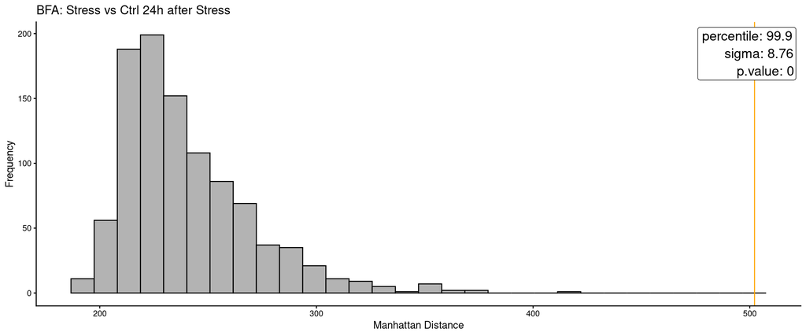

```r
set.seed(123)

  x <- plotTransVF(US, labels = US$label_names[2],title = "BFA: Stress vs Ctrl 24h after Stress")
  print(x)
```

```r
  ggsave("sup_plots/Fig3D_father_OFT1_UMAP.pdf")
  ggsave("sup_plots/Fig3D_father_OFT1_UMAP.png")
  ggsave("sup_plots/Fig3D_father_OFT1_UMAP.svg")
```

# 12 Fig 3E GR-ChIP sperm IFS waterfall

```r
bw <- list.files(path = "intern_data/ChIP/",pattern = "*.bw$",full.names = T)
names(bw) <- basename(bw)

bw <- bw[!grepl(pattern = "Input",bw)]




GR_bed <- sapply(names(bw),function(names){
  import.bw(bw[names])
})
```

import peaks

```r
se <- readRDS("intern_data/ChIP/GR_counts_non_resized.SE.rds")


GRpeaks <- granges(se)
```

```r
sm_GR <-  signal2Matrix(filepaths = GR_bed,regions = GRpeaks,w = 10L,smooth = T, background= 0)
sm_merge_GR_Ctrl <- mergeSignalMatrices(epiwraps:::.ese2ml(sm_GR[,1:4]))
sm_merge_GR_Stress <- mergeSignalMatrices(epiwraps:::.ese2ml(sm_GR[,5:8]))
```

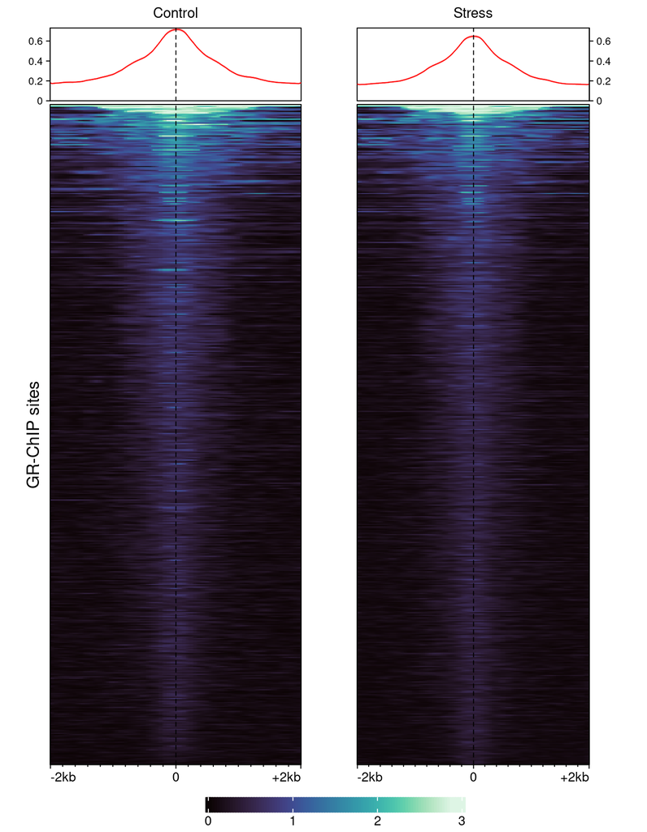

```r
p_GR1 <-  plotEnrichedHeatmaps(ml = list(Control = sm_merge_GR_Ctrl, Stress = sm_merge_GR_Stress),row_title = "GR-ChIP sites",scale_title = "GR\ndesnity",colors = mako(2000), raster_resize_mat = TRUE, use_raster = TRUE,axis_name = c("-2kb","0","+2kb"), trim = c(0.01,0.99),width = unit(0.8,"npc"), heatmap_legend_param = list(legend_direction = "horizontal", legend_width = unit(0.4,"npc"), title=NULL))



  draw(p_GR1, heatmap_legend_side="bottom", annotation_legend_side="right",  legend_grouping = "original")
```

```r
  png(paste0("plots/Fig3E.png"), width=500, height=750)
  draw(p_GR1, heatmap_legend_side="bottom", annotation_legend_side="right",  legend_grouping = "original")
  dev.off()
```

```r
  pdf(paste0("plots/Fig3E.pdf"), width=5, height=7.5)
  draw(p_GR1, heatmap_legend_side="bottom", annotation_legend_side="right",  legend_grouping = "original")
  dev.off()
```

```r
  svg(paste0("plots/Fig3E.svg"), width=5, height=7.5)
  draw(p_GR1, heatmap_legend_side="bottom", annotation_legend_side="right",  legend_grouping = "original")
  dev.off()
```